# CMVI

2025-08-31

This is work is based Christen and Rubio (2024) ODE Survival Model. We provide computationally efficient methods alternative to MCMC sampling.

#Normal Approximation# First, we construct a normal approximation using Laplace approximation.

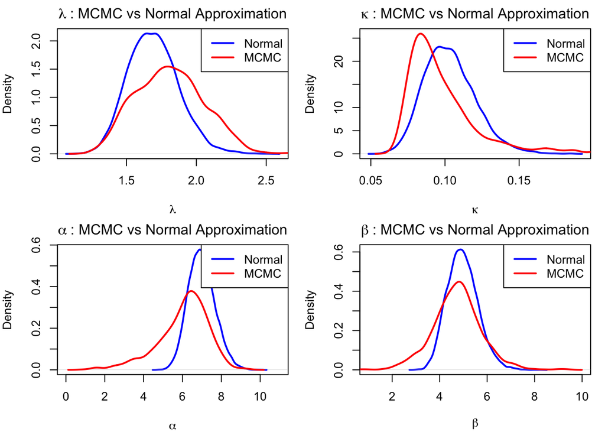

```r
library(deSolve)
load("Ex2.RData")

library(numDeriv)

MAP = nlminb(inits, log_postHR, control = list(iter.max = 1e4))$par


hess = hessian(func = log_postHR, x = MAP)


Sigma = solve(hess)

sigmas_napp = sqrt(diag(Sigma))

library(mvtnorm)

set.seed(123)
post_napp = rmvnorm(n = 10000, mean = MAP, sigma = Sigma)


# Graphs for comparisons between mcmc and normal approximation
par(mfrow=c(2,2), mar=c(4,4,2,1))

# lambda
plot(density(exp(post_napp[,1])), main= expression(lambda ~ ": MCMC vs Normal Approximation"),
     lwd = 2, col = "blue", xlab=expression(lambda), ylab = "Density")
lines(density(lambdapHR), lwd = 2, col = "red")
legend("topright", c("Normal","MCMC"), col=c("blue","red"), lwd=2)

# kappa
plot(density(exp(post_napp[,2])), main = expression(kappa ~ ": MCMC vs Normal Approximation"),
     lwd = 2, col = "blue", xlab = expression(kappa), ylab = "Density", ylim=c(0,26))
lines(density(kappapHR), lwd = 2, col = "red")
legend("topright", c("Normal","MCMC"), col=c("blue","red"), lwd=2)

# alpha
plot(density(exp(post_napp[,3])), main = expression(alpha ~ ": MCMC vs Normal Approximation"),
     lwd = 2, col = "blue", xlab = expression(alpha), ylab = "Density", xlim = c(0,11))
lines(density(alphapHR), lwd = 2, col = "red")
legend("topright", c("Normal","MCMC"), col=c("blue","red"), lwd=2)

# beta
plot(density(exp(post_napp[,4])), main = expression(beta ~ ": MCMC vs Normal Approximation"),
     lwd = 2, col = "blue", xlab = expression(beta), ylab = "Density", xlim = c(1,10))
lines(density(betapHR), lwd = 2, col = "red")
legend("topright", c("Normal","MCMC"), col=c("blue","red"), lwd=2)
```

From the Normal Approximation result we see that it captures most of the MCMC result, especially around the mode. However, as the normal approximation results in a symmetric density, it fails to capture tail behaviours and skewness. Therefore, we want to further consider flexible approximations such as variational inference and least square density fitting.

#Least Square Density Fitting# We also construct a Least Square Density Fitting. We define a grid for each parameter space and minimise the mean square error.

```r
# install.packages(c("deSolve", "survival", "devtools"))
library(deSolve)
library(survival)
library(devtools)
# install_github("FJRubio67/twopiece")
library(twopiece)

source("routines.R")

#################################################################################
# Data preparation
#################################################################################

head(rotterdam)
```

```
##      pid year age meno  size grade nodes pgr  er hormon chemo rtime recur dtime
## 1393   1 1992  74    1  <=20     3     0  35 291      0     0  1799     0  1799
## 1416   2 1984  79    1 20-50     3     0  36 611      0     0  2828     0  2828
## 2962   3 1983  44    0  <=20     2     0 138   0      0     0  6012     0  6012
## 1455   4 1985  70    1 20-50     3     0   0  12      0     0  2624     0  2624
## 977    5 1983  75    1  <=20     3     0 260 409      0     0  4915     0  4915
## 617    6 1983  52    0  <=20     3     0 139 303      0     0  5888     0  5888
##      death
## 1393     0
## 1416     0
## 2962     0
## 1455     0
## 977      0
## 617      0
```

```r
dim(rotterdam)
```

```
## [1] 2982   15
```

```r
# New data frame: logical status, time in years, survival times sorted
df <- data.frame(time = rotterdam$dtime, status = rotterdam$death)
df$status <- as.logical(rotterdam$death)
df$time <- df$time/365.24

df <- df[order(df$time),]

# Required quantities
status <- as.logical(df$status)
t_obs <- df$time[status]
survtimes <- df$time


#################################################################################
# Define the parameter grids and the log posterior
#################################################################################

par1_grid <- seq(from = 0, to = 3,  length.out = 10)
par2_grid <- seq(from = -3, to = 3,  length.out = 10)
par3_grid <- seq(from = 0, to = 11,  length.out = 10)
par4_grid <- seq(from = 0, to = 11,  length.out = 10)

param_combinations <- expand.grid(par1 = par1_grid,
                                  par2 = par2_grid,
                                  par3 = par3_grid,
                                  par4 = par4_grid)
eta_grid  <- as.matrix(param_combinations)


N <- nrow(eta_grid)
log_p <- numeric(N)
for (i in 1:N) {
  log_p[i] <- -log_postHRL(eta_grid[i,])
}


#################################################################################
# LSE function
#################################################################################

sim = chainHR[ind,]

LSE <- function(phi, eta, log_p){


  # Calculate log_q using the pre-calculated grid.

  mu <- phi_init_lse[1:4]
  sigma1 <- exp(phi_init_lse[5:8])
  sigma2 <- exp(phi_init_lse[9:12])

  log_q_matrix <- matrix(NA, nrow = nrow(eta_grid), ncol = 4)

  for (j in 1:nrow(eta_grid)) {
    for (i in 1:4) {
      log_q_matrix[j,i] <- dtp3(eta_grid[j,i], mu[i], sigma1[i], sigma2[i], FUN = dnorm, log = TRUE )
    }
  }


  if (any(!is.finite(log_q_matrix))) {
    return(.Machine$double.xmax)
  }

  log_q <- rowSums(log_q_matrix)

  # Calculate MSE against the pre-calculated log_p vector.
  mse <- mean( (log_p - log_q)^2)

  return(mse)
}


#################################################################################
# Optimisation
#################################################################################
sim <- chainHR[ind,]

nloglik <- function(par){

  mu <- par[1:4]
  sigma1 <- exp(par[5:8])
  sigma2 <- exp(par[9:12])

  # Calculate log_q using the pre-calculated grid.

  log_q_matrix <- matrix(NA, nrow = nrow(sim), ncol = ncol(sim))

  log_q_matrix <- matrix(
    mapply(function(x, i) dtp3(x, mu[i], sigma1[i], sigma2[i], FUN = dnorm, log = TRUE),
           x = as.vector(sim),
           i = rep(1:4, each = nrow(sim))),
    nrow = nrow(sim), ncol = 4, byrow = FALSE
  )


  out <- -sum(log_q_matrix)

return(out)

}


OPT <- nlminb(start = c(rep(0,4),rep(1,8)), objective = nloglik, control = list(iter.max = 10000))



phi_init_lse = OPT$par

set.seed(1234)

output_lse <- nlminb(phi_init_lse, LSE,
                 eta = eta_grid,
                 log_p = log_p,
                 control = list(iter.max = 1e4, trace = 1))
```

```
##   0: 3.3556631e+17: 0.598869 -2.56967  1.98031  1.63661 -1.94564 -2.99244 -0.996351 -1.18345 -2.06990 -1.01119 -2.56677 -1.85613
##   1: 3.3556631e+17: 0.598869 -2.56967  1.98031  1.63661 -1.94564 -2.99244 -0.996351 -1.18345 -2.06990 -1.01119 -2.56677 -1.85613
```

```r
phi_lse <- output_lse$par

#################################################################################
# Result
#################################################################################

mu_lse = phi_lse[1:4]
sigma1_lse = exp(phi_lse[5:8])
sigma2_lse = exp(phi_lse[9:12])

eta_samples_lse = cbind(rtp3(10000, mu_lse[1], sigma1_lse[1], sigma2_lse[1], FUN = rnorm),
                    rtp3(10000, mu_lse[2], sigma1_lse[2], sigma2_lse[2], FUN = rnorm),
                    rtp3(10000, mu_lse[3], sigma1_lse[3], sigma2_lse[3], FUN = rnorm),
                    rtp3(10000, mu_lse[4], sigma1_lse[4], sigma2_lse[4], FUN = rnorm))

theta_samples_lse <- as.data.frame(exp(eta_samples_lse))
colnames(theta_samples_lse) <- c("lambda", "kappa", "alpha", "beta")

summary(theta_samples_lse)
```

```
##      lambda          kappa             alpha            beta
##  Min.   :1.027   Min.   :0.06558   Min.   :1.929   Min.   :1.631
##  1st Qu.:1.644   1st Qu.:0.08201   1st Qu.:4.944   1st Qu.:3.932
##  Median :1.801   Median :0.09397   Median :5.965   Median :4.677
##  Mean   :1.814   Mean   :0.10136   Mean   :5.883   Mean   :4.680
##  3rd Qu.:1.973   3rd Qu.:0.11269   3rd Qu.:6.907   3rd Qu.:5.404
##  Max.   :2.887   Max.   :0.30887   Max.   :9.779   Max.   :9.513
```

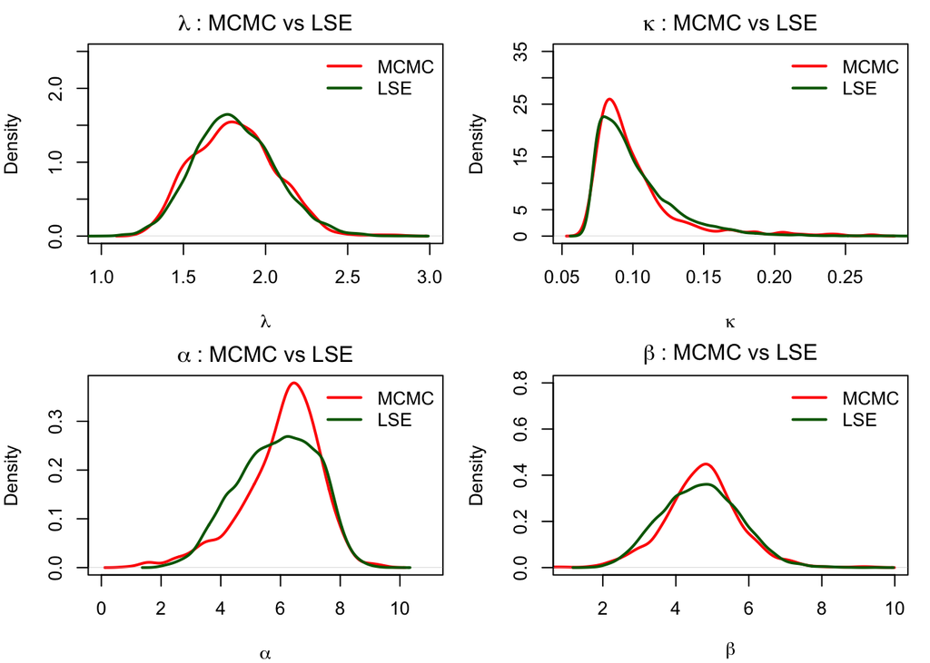

```r
###################################################################################
# Graphs Comparison
###################################################################################
par(mfrow=c(2,2), mar=c(4,4,2,1))

# lambda
plot(density(lambdapHR), main = expression(lambda ~ ": MCMC vs LSE"),
     lwd = 2, col = "red", xlab = expression(lambda), ylab = "Density", xlim = c(1,3), ylim = c(0,2.5))
lines(density(theta_samples_lse$lambda), lwd = 2, col = "darkgreen")
legend("topright", c("MCMC", "LSE"), col = c("red", "darkgreen"), lwd = 2, bty = "n")

# kappa
plot(density(kappapHR), main = expression(kappa ~ ": MCMC vs LSE"),
     lwd = 2, col = "red", xlab = expression(kappa), ylab = "Density", ylim = c(0,35))
lines(density(theta_samples_lse$kappa), lwd = 2, col = "darkgreen")
legend("topright", c("MCMC", "LSE"), col = c("red", "darkgreen"), lwd = 2, bty = "n")

# alpha
plot(density(alphapHR), main = expression(alpha ~ ": MCMC vs LSE"),
     lwd = 2, col = "red", xlab = expression(alpha), ylab = "Density", xlim = c(0,11))
lines(density(theta_samples_lse$alpha), lwd = 2, col = "darkgreen")
legend("topright", c("MCMC", "LSE"), col = c("red", "darkgreen"), lwd = 2, bty = "n")

# beta
plot(density(betapHR), main = expression(beta ~ ": MCMC vs LSE"),
     lwd = 2, col = "red", xlab = expression(beta), ylab = "Density", xlim = c(1,10), ylim = c(0,0.8))
lines(density(theta_samples_lse$beta), lwd = 2, col = "darkgreen")
legend("topright", c("MCMC", "LSE"), col = c("red", "darkgreen"), lwd = 2, bty = "n")
```

#Variational Inference using independent two-piece normals# We first consider using a variational inference using independent two-piece normals as the variational distribution. We do a monte-carlo ELBO.

```r
library(deSolve)
library(survival)
library(devtools)
# install_github("FJRubio67/twopiece")
library(twopiece)
library(optimx)

source("routines.R")


#################################################################################
# Monte Carlo function of the ELBO
#################################################################################

mc_elbo <- function(phi, N = 5000){

  mu = phi[1:4]
  sigma1 = exp(phi[5:8])
  sigma2 = exp(phi[9:12])

  # Sample from the variational distribution

  # eps = matrix(rnorm(N*4), ncol = 4)

  eta = cbind(rtp3(N, mu[1], sigma1[1], sigma2[1], FUN = rnorm),
              rtp3(N, mu[2], sigma1[2], sigma2[2], FUN = rnorm),
              rtp3(N, mu[3], sigma1[3], sigma2[3], FUN = rnorm),
              rtp3(N, mu[4], sigma1[4], sigma2[4], FUN = rnorm))

  # Calculate the ELBO



  log_p = numeric(N) # create an empty vector to store log p(y, θ)
  for (i in 1:N) {
    log_p[i] = -log_postHRL(eta[i,])
  }



  # Term 2: E[log q(η)]

  log_q_matrix = matrix(NA, nrow = N, ncol = 4)

  for (i in 1:4) {
    log_q_matrix[,i] = dtp3(eta[,i], mu[i], sigma1[i], sigma2[i], FUN = dnorm, log = TRUE )
  }



  log_q = rowSums(log_q_matrix)

  elbo = mean(log_p - log_q)

  return(-elbo)
}


#################################################################################
# Optimisation
#################################################################################

phi_init = OPT$par

set.seed(42)

output = nlminb(phi_init, mc_elbo, control = list(iter.max = 1e4, trace = 1))
```

```
##   0:     4818.8805: 0.598869 -2.56967  1.98031  1.63661 -1.94564 -2.99244 -0.996351 -1.18345 -2.06990 -1.01119 -2.56677 -1.85613
##   1:     4805.8242: 0.565584 -2.62093  1.90309  1.78850 -2.18670 -3.00695 -1.18744 -0.975624 -2.00477 -1.25166 -2.69678 -1.87151
##   2:     4805.5633: 0.566149 -2.62101  1.90462  1.78821 -2.18629 -3.00601 -1.18820 -0.974994 -2.00276 -1.25079 -2.69720 -1.87861
##   3:     4805.2124: 0.566203 -2.62110  1.90461  1.78748 -2.18640 -3.00603 -1.18936 -0.974832 -2.00240 -1.24960 -2.69772 -1.87866
##   4:     4805.2124: 0.566203 -2.62110  1.90461  1.78748 -2.18640 -3.00603 -1.18936 -0.974832 -2.00240 -1.24960 -2.69772 -1.87866
```

```r
phi = output$par

print(phi)
```

```
##  [1]  0.5662025 -2.6210994  1.9046138  1.7874759 -2.1864014 -3.0060253
##  [7] -1.1893630 -0.9748318 -2.0023957 -1.2495994 -2.6977158 -1.8786551
```

```r
#################################################################################
# Results
#################################################################################

mu = phi[1:4]
sigma1 = exp(phi[5:8])
sigma2 = exp(phi[9:12])

eta_samples = cbind(rtp3(10000, mu[1], sigma1[1], sigma2[1], FUN = rnorm),
                    rtp3(10000, mu[2], sigma1[2], sigma2[2], FUN = rnorm),
                    rtp3(10000, mu[3], sigma1[3], sigma2[3], FUN = rnorm),
                    rtp3(10000, mu[4], sigma1[4], sigma2[4], FUN = rnorm))

theta_samples <- as.data.frame(exp(eta_samples))
colnames(theta_samples) <- c("lambda", "kappa", "alpha", "beta")

summary(theta_samples)
```

```
##      lambda          kappa             alpha            beta
##  Min.   :1.211   Min.   :0.06080   Min.   :2.159   Min.   : 1.489
##  1st Qu.:1.648   1st Qu.:0.07609   1st Qu.:4.923   1st Qu.: 4.209
##  Median :1.787   Median :0.08517   Median :5.753   Median : 5.174
##  Mean   :1.807   Mean   :0.08956   Mean   :5.663   Mean   : 5.181
##  3rd Qu.:1.947   3rd Qu.:0.09831   3rd Qu.:6.501   3rd Qu.: 6.109
##  Max.   :2.870   Max.   :0.21365   Max.   :8.285   Max.   :10.401
```

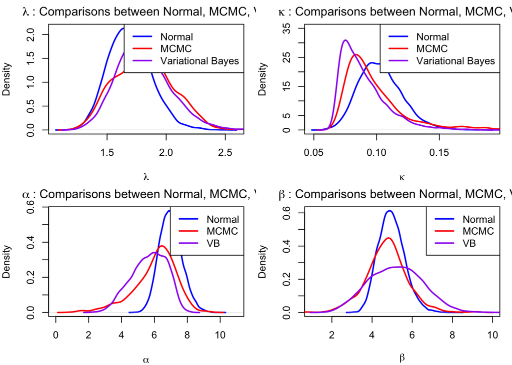

```r
#################################################################################
# Plots for Comparisons
#################################################################################
par(mfrow=c(2,2), mar=c(4,4,2,1))

# Plot for lambda
plot(density(exp(post_napp[,1])), main= expression(lambda ~ ": Comparisons between Normal, MCMC, VB"),
     lwd = 2, col = "blue", xlab=expression(lambda), ylab = "Density")
lines(density(lambdapHR), lwd = 2, col = "red")
lines(density(theta_samples$lambda), lwd = 2, col = "purple")
legend("topright", c("Normal","MCMC", "Variational Bayes"), col=c("blue","red", "purple"), lwd=2)


# kappa
plot(density(exp(post_napp[,2])), main = expression(kappa ~ ": Comparisons between Normal, MCMC, VB"),
     lwd = 2, col = "blue", xlab = expression(kappa), ylab = "Density", ylim = c(0,35))
lines(density(kappapHR), lwd = 2, col = "red")
lines(density(theta_samples$kappa), lwd = 2, col = "purple")
legend("topright", c("Normal","MCMC", "Variational Bayes"), col=c("blue","red", "purple"), lwd=2)


# alpha
plot(density(exp(post_napp[,3])), main = expression(alpha ~ ": Comparisons between Normal, MCMC, VB"),
     lwd = 2, col = "blue", xlab = expression(alpha), ylab = "Density", xlim = c(0,11))
lines(density(alphapHR), lwd = 2, col = "red")
lines(density(theta_samples$alpha), lwd = 2, col = "purple")
legend("topright", c("Normal","MCMC", "VB"), col=c("blue","red", "purple"), lwd=2)


# beta
plot(density(exp(post_napp[,4])), main = expression(beta ~ ": Comparisons between Normal, MCMC, VB"),
     lwd = 2, col = "blue", xlab = expression(beta), ylab = "Density", xlim = c(1,10))
lines(density(betapHR), lwd = 2, col = "red")
lines(density(theta_samples$beta), lwd = 2, col = "purple")
legend("topright", c("Normal","MCMC", "VB"), col=c("blue","red", "purple"), lwd=2)
```

#Copula-Marginal Variational Inference using Gaussian Copula and Two-piece normal marginals#

In this section, we provide a copula-marginal variational inference. We also adopted importance-weighted ELBO and self-normalised importance sampling.

```r
qtp3 <- function (p, mu, par1, par2, FUN) {
  eps <- 1e-10
  split_point <- par1 / (par1 + par2)
  is_left <- p < split_point
  is_right <- !is_left

  arg_left <- 0.5 * p[is_left] * (par1 + par2) / par1
  arg_right <- 0.5 * ((par1 + par2) * (1 + p[is_right]) - 2 * par1) / par2

  Q <- numeric(length(p))

  if(any(is_left)) {
    Q[is_left] <- mu + par1 * FUN(pmin(pmax(arg_left, eps), 1 - eps))
  }
  if(any(is_right)) {
    Q[is_right] <- mu + par2 * FUN(pmin(pmax(arg_right, eps), 1 - eps))
  }

  return(Q)
}

#################################################################################
# Monte Carlo function of the ELBO
#################################################################################

library(MASS)
library(mvtnorm)

# phi: [1:4]=mu, [5:8]=log(sigma1), [9:12]=log(sigma2), [13:18]=psi
mc_elbo <- function(phi, N = 10000) {

  mu   <- phi[1:4]
  s1   <- exp(phi[5:8])
  s2   <- exp(phi[9:12])
  psi  <- phi[13:18]
  rhos <- 2 * plogis(psi) - 1

  R <- matrix(c(
    1,        rhos[1], rhos[2], rhos[3],
    rhos[1],  1,       rhos[4], rhos[5],
    rhos[2],  rhos[4], 1,       rhos[6],
    rhos[3],  rhos[5], rhos[6], 1
  ), nrow = 4, byrow = TRUE)


  if (inherits(try(chol(R), silent = TRUE), "try-error")) {
    return(.Machine$double.xmax)
  }

  Z <- mvrnorm(n = N, mu = rep(0, 4), Sigma = R)
  U <- pnorm(Z)

  eta <- cbind(
    qtp3(U[,1], mu[1], s1[1], s2[1], FUN = qnorm),
    qtp3(U[,2], mu[2], s1[2], s2[2], FUN = qnorm),
    qtp3(U[,3], mu[3], s1[3], s2[3], FUN = qnorm),
    qtp3(U[,4], mu[4], s1[4], s2[4], FUN = qnorm)
  )

  ##  Term 1: E_q[log p(y, η)]
  log_p <- vapply(seq_len(N), function(i) -log_postHRL(eta[i, ]), numeric(1))

  ##  Term 2: E_q[log q(η)]
  log_q_marg <-
    dtp3(eta[,1], mu[1], s1[1], s2[1], FUN = dnorm, log = TRUE) +
    dtp3(eta[,2], mu[2], s1[2], s2[2], FUN = dnorm, log = TRUE) +
    dtp3(eta[,3], mu[3], s1[3], s2[3], FUN = dnorm, log = TRUE) +
    dtp3(eta[,4], mu[4], s1[4], s2[4], FUN = dnorm, log = TRUE)

  log_phi_R  <- mvtnorm::dmvnorm(Z, sigma = R, log = TRUE)
  log_phi_id <- rowSums(dnorm(Z, log = TRUE))
  log_cop    <- log_phi_R - log_phi_id

  log_q <- log_q_marg + log_cop

  -mean(log_p - log_q)
}
#################################################################################
# Importance-Weighted Monte Carlo ELBO
#################################################################################
logmeanexp <- function(v){ m <- max(v); m + log(mean(exp(v - m))) }

mc_elbo <- function(phi, N = 5000, M = 10){
  N_use <- (N %/% M) * M
  mu   <- phi[1:4]
  s1   <- exp(phi[5:8])
  s2   <- exp(phi[9:12])
  psi  <- phi[13:18]
  rhos <- 2 * plogis(psi) - 1

  R <- matrix(c(
    1, rhos[1], rhos[2], rhos[3],
    rhos[1], 1, rhos[4], rhos[5],
    rhos[2], rhos[4], 1, rhos[6],
    rhos[3], rhos[5], rhos[6], 1
  ), 4, 4, byrow = TRUE)
  if (inherits(try(chol(R), silent = TRUE), "try-error")) return(.Machine$double.xmax)

  Z <- MASS::mvrnorm(n = N_use, mu = rep(0,4), Sigma = R)
  U <- pnorm(Z)

  eta <- cbind(
    qtp3(U[,1], mu[1], s1[1], s2[1], FUN = qnorm),
    qtp3(U[,2], mu[2], s1[2], s2[2], FUN = qnorm),
    qtp3(U[,3], mu[3], s1[3], s2[3], FUN = qnorm),
    qtp3(U[,4], mu[4], s1[4], s2[4], FUN = qnorm)
  )

  # E_q[log p(y,eta)]
  log_p <- vapply(seq_len(N_use), function(i) -log_postHRL(eta[i, ]), numeric(1))

  # E_q[log q(eta)] = ∑ log dtp3 + log copula
  log_q_marg <-
    dtp3(eta[,1], mu[1], s1[1], s2[1], FUN = dnorm, log = TRUE) +
    dtp3(eta[,2], mu[2], s1[2], s2[2], FUN = dnorm, log = TRUE) +
    dtp3(eta[,3], mu[3], s1[3], s2[3], FUN = dnorm, log = TRUE) +
    dtp3(eta[,4], mu[4], s1[4], s2[4], FUN = dnorm, log = TRUE)

  log_phi_R  <- mvtnorm::dmvnorm(Z, sigma = R, log = TRUE)
  log_phi_id <- rowSums(dnorm(Z, log = TRUE))
  log_q <- log_q_marg + (log_phi_R - log_phi_id)

  log_w <- log_p - log_q
  L <- matrix(log_w[1:((N_use/M)*M)], ncol = M, byrow = TRUE)
  iw_elbo <- mean(apply(L, 1, logmeanexp)) - log(M)
  -iw_elbo
}

#################################################################################
# Optimisation
#################################################################################
phi_init <- c(OPT$par, rep(0, 6))

set.seed(42)
out1 <- nlminb(phi_init, mc_elbo, N = 1000, M = 10, control = list(iter.max = 1e4, trace = 1))
```

```
##   0:     4793.8579: 0.598869 -2.56967  1.98031  1.63661 -1.94564 -2.99244 -0.996351 -1.18345 -2.06990 -1.01119 -2.56677 -1.85613  0.00000  0.00000  0.00000  0.00000  0.00000  0.00000
##   1:     4793.8444: 0.577217 -2.56711  1.97725  1.64253 -1.95317 -2.99945 -1.04194 -1.18013 -2.07040 -1.01049 -2.57742 -1.87365 -0.00168661 0.0115044 0.0114066 0.0212175 0.00406672 0.00615293
##   2:     4793.6665: 0.577160 -2.56709  1.97720  1.64255 -1.95332 -2.99949 -1.04190 -1.18013 -2.07046 -1.01043 -2.57741 -1.87369 -0.00162235 0.0115331 0.0115090 0.0212018 0.00409335 0.00614642
##   3:     4793.6665: 0.577160 -2.56709  1.97720  1.64255 -1.95332 -2.99949 -1.04190 -1.18013 -2.07046 -1.01043 -2.57741 -1.87369 -0.00162235 0.0115331 0.0115090 0.0212018 0.00409335 0.00614642
```

```r
out2 <- nlminb(out1$par, mc_elbo, N = 5000, M = 10, control = list(iter.max = 1e4, trace = 1))
```

```
##   0:     4793.9453: 0.577160 -2.56709  1.97720  1.64255 -1.95332 -2.99949 -1.04190 -1.18013 -2.07046 -1.01043 -2.57741 -1.87369 -0.00162235 0.0115331 0.0115090 0.0212018 0.00409335 0.00614642
##   1:     4793.8161: 0.581044 -2.56797  1.97540  1.64073 -1.95264 -2.99867 -1.04072 -1.18261 -2.07160 -1.00649 -2.57776 -1.87470 -0.00244114 0.0100572 0.0114466 0.0185300 0.00318964 0.00505965
##   2:     4793.8161: 0.581044 -2.56797  1.97540  1.64073 -1.95264 -2.99867 -1.04072 -1.18261 -2.07160 -1.00649 -2.57776 -1.87470 -0.00244114 0.0100572 0.0114466 0.0185300 0.00318964 0.00505965
```

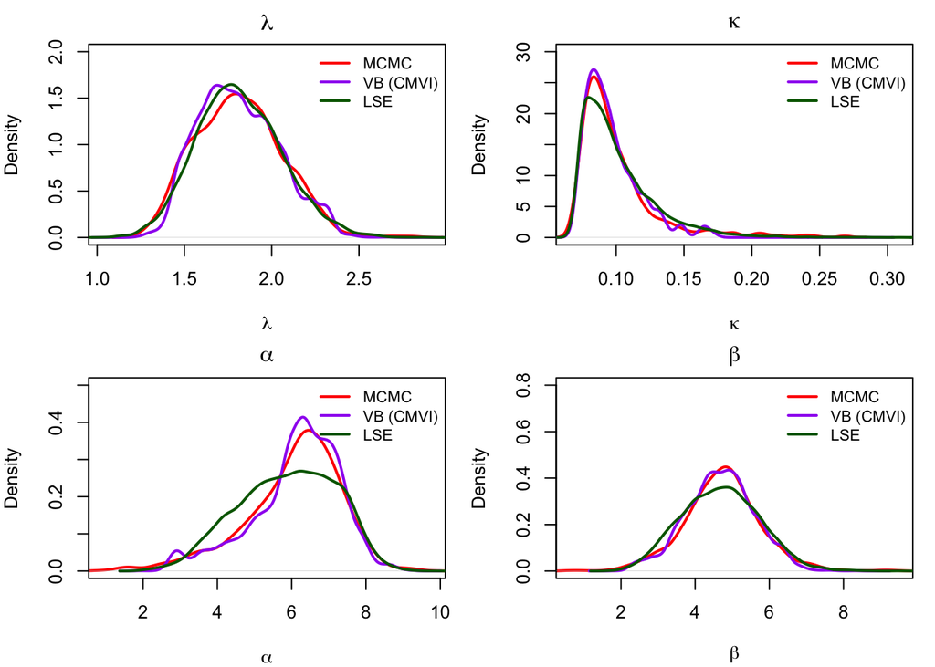

```r
phi  <- out2$par

#################################################################################
# Normalised Importance Sampling (NIS)
#################################################################################
mu     <- phi[1:4]
sigma1 <- exp(phi[5:8])
sigma2 <- exp(phi[9:12])
psi    <- phi[13:18]
rhos   <- 2 * plogis(psi) - 1

R <- matrix(c(1, rhos[1], rhos[2], rhos[3],
              rhos[1], 1, rhos[4], rhos[5],
              rhos[2], rhos[4], 1, rhos[6],
              rhos[3], rhos[5], rhos[6], 1), 4, 4, byrow = TRUE)

set.seed(123)
Zs <- mvrnorm(n = 10000, mu = rep(0, 4), Sigma = R)
Us <- pnorm(Zs)
etas <- cbind(
  qtp3(Us[,1], mu[1], sigma1[1], sigma2[1], FUN = qnorm),
  qtp3(Us[,2], mu[2], sigma1[2], sigma2[2], FUN = qnorm),
  qtp3(Us[,3], mu[3], sigma1[3], sigma2[3], FUN = qnorm),
  qtp3(Us[,4], mu[4], sigma1[4], sigma2[4], FUN = qnorm)
)

thetas <- as.data.frame(exp(etas))
names(thetas) <- c("lambda","kappa","alpha","beta")

# log q and log p
log_q_marg <- twopiece::dtp3(etas[,1], mu[1], sigma1[1], sigma2[1], FUN = dnorm, log = TRUE) +
  twopiece::dtp3(etas[,2], mu[2], sigma1[2], sigma2[2], FUN = dnorm, log = TRUE) +
  twopiece::dtp3(etas[,3], mu[3], sigma1[3], sigma2[3], FUN = dnorm, log = TRUE) +
  twopiece::dtp3(etas[,4], mu[4], sigma1[4], sigma2[4], FUN = dnorm, log = TRUE)
log_q_samp <- log_q_marg + (mvtnorm::dmvnorm(Zs, sigma = R, log = TRUE) - rowSums(dnorm(Zs, log = TRUE)))

log_p_samp <- vapply(seq_len(nrow(etas)), function(i) -log_postHRL(etas[i, ]), numeric(1))

# NIS weights
lw <- log_p_samp - log_q_samp
w  <- exp(lw - max(lw))
w  <- w / sum(w)

#################################################################################
# Graphs
#################################################################################
par(mfrow=c(2,2), mar=c(4,4,2,1))

# λ
plot(density(lambdapHR), main=expression(lambda), lwd=2, col="red",
     xlab=expression(lambda), ylab="Density", ylim = c(0,2), xlim = range(c(lambdapHR, thetas$lambda, theta_samples_lse$lambda)))
lines(density(thetas$lambda, weights = w, bw = bw.nrd0(thetas$lambda)), lwd=2, col="purple")
lines(density(theta_samples_lse$lambda), lwd=2, col="darkgreen")
legend("topright", c("MCMC","VB (CMVI)","LSE"),
       col=c("red","purple","darkgreen"), lwd=2, bty="n", cex=0.85)

# κ
plot(density(kappapHR), main=expression(kappa), lwd=2, col="red",
     xlab=expression(kappa), ylab="Density",
     xlim = range(c(kappapHR, thetas$kappa, theta_samples_lse$kappa)),
     ylim=c(0,30))
lines(density(thetas$kappa, weights = w, bw = bw.nrd0(thetas$kappa)), lwd=2, col="purple")
lines(density(theta_samples_lse$kappa), lwd=2, col="darkgreen")
legend("topright", c("MCMC","VB (CMVI)","LSE"),
       col=c("red","purple","darkgreen"), lwd=2, bty="n", cex=0.85)

# α
plot(density(alphapHR), main=expression(alpha), lwd=2, col="red",
     xlab=expression(alpha), ylab="Density",
     xlim = range(c(alphapHR, thetas$alpha, theta_samples_lse$alpha)),
     ylim = c(0,0.5))
lines(density(thetas$alpha, weights = w, bw = bw.nrd0(thetas$alpha)), lwd=2, col="purple")
lines(density(theta_samples_lse$alpha), lwd=2, col="darkgreen")
legend("topright", c("MCMC","VB (CMVI)","LSE"),
       col=c("red","purple","darkgreen"), lwd=2, bty="n", cex=0.85)

# β
plot(density(betapHR), main=expression(beta), lwd=2, col="red",
     xlab=expression(beta), ylab="Density",
     xlim = range(c(betapHR, thetas$beta, theta_samples_lse$beta)),
     ylim = c(0,0.8))
lines(density(thetas$beta, weights = w, bw = bw.nrd0(thetas$beta)), lwd=2, col="purple")
lines(density(theta_samples_lse$beta), lwd=2, col="darkgreen")
legend("topright", c("MCMC","VB (CMVI)","LSE"),
       col=c("red","purple","darkgreen"), lwd=2, bty="n", cex=0.85)
```

We compare the 2D joint posterior distributions obtained from MCMC (red) and VB (CMVI, skyblue)

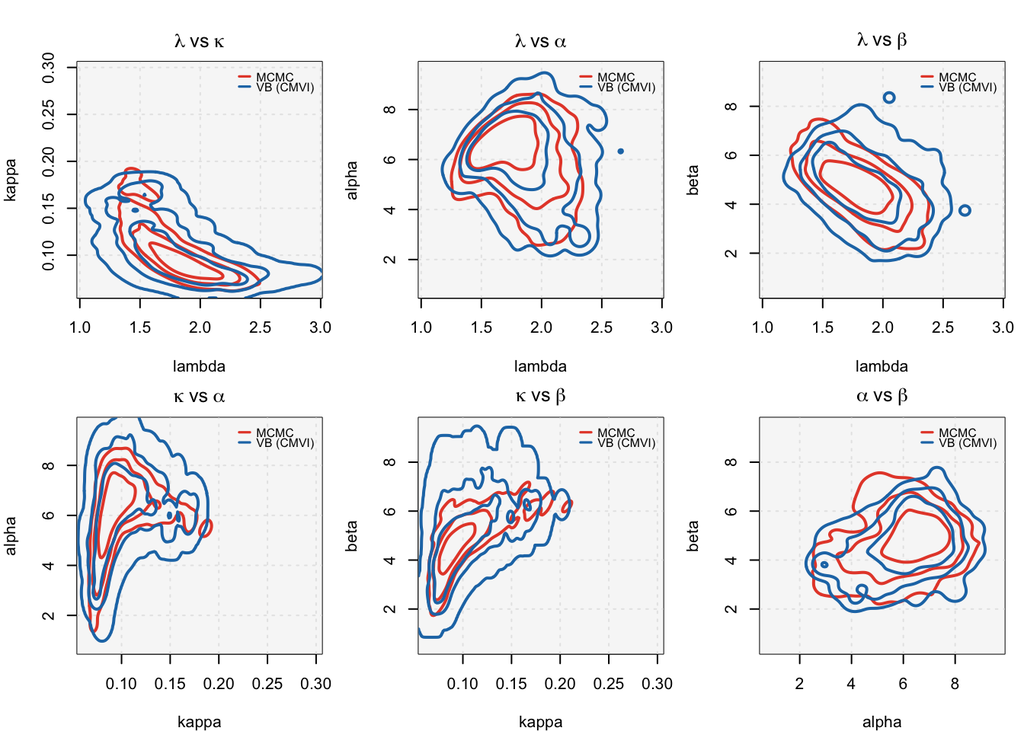